# Assignment 2: Hand Gesture Recognition [50 Pt]

This assignment will be completed in two parts. In Part A you will gain experience gathering your own data set (specifically images of hand gestures), and understand the challenges involved in the data cleaning process. In Part B you will train a convolutional neural network to make classifications on different hand gestures. By the end of this assignment, you should be able to:

1. Generate and preprocess your own data
2. Load and split data for training, validation and testing
3. Train a Convolutional Neural Network
4. Apply transfer learning to improve your model

Note that for this assignment we will not be providing you with any starter code. You should be able to take the sample code provided in the preparation sample code, previous assignment, and lectures and modify it accordingly to complete the tasks outlined below.

*This assignment is based on an assignment developed by Prof. Lisa Zhang.*

### What to submit

**Submission for Part A:**  
Submit a zip file containing your images. Three images each of American Sign Language gestures for letters A - I (total of 27 images). You will be required to clean the images before submitting them. Details are provided under Part A of the handout.

Individual image file names should follow the convention of student-number_Alphabet_file-number.jpg (e.g. 100343434_A_1.jpg).

**Submission for Part B:**  
Submit an HTML file containing all your code, outputs, and write-up from parts A and B. You can produce a HTML file directly from Google Colab. The Colab instructions are provided at the end of this document.

**Do not submit any other files produced by your code.**

Include a link to your colab file in your submission.

Please use Google Colab to complete this assignment. If you want to use Jupyter Notebook, please complete the assignment and upload your Jupyter Notebook file to Google Colab for submission.

## Colab Link

Include a link to your colab file here and ensure the file can be accessed by the our teaching team.

```python
# TO BE COMPLETED

https://drive.google.com/file/d/1QLaUx_ZRk3koTl91llOXKldpBlB6wDoD/view?usp=sharing
```

# Part A. Data Collection [5pt]

So far, we have worked with data sets that have been collected, cleaned, and curated by machine learning researchers and practitioners. Datasets like MNIST and CIFAR are often used as toy examples, both by students and by researchers testing new machine learning models.

In the real world, getting a clean data set is never that easy. More than half the work in applying machine learning is finding, gathering, cleaning, and formatting your data set.

The purpose of this assignment is to help you gain experience gathering your own data set, and understand the challenges involved in the data cleaning process.

### American Sign Language

American Sign Language (ASL) is a complete, complex language that employs signs made by moving the hands combined with facial expressions and postures of the body. It is the primary language of many North Americans who are deaf and is one of several communication options used by people who are deaf or hard-of-hearing.

The hand gestures representing English alphabet are shown below. This assignment focuses on classifying a subset of these hand gesture images using convolutional neural networks. Specifically, given an image of a hand showing one of the letters A-I, we want to detect which letter is being represented.

[figure not shown]

### Generating Data

We will produce the images required to assess our models by ourselves. You are required to collect, clean and submit three images each of Americal Sign Language gestures for letters A - I (total of 27 images) Steps involved in data collection

1. Familiarize yourself with American Sign Language gestures for letters from A - I (9 letters).
2. Take three pictures at slightly different orientation for each letter gesture using your mobile phone.
   - Ensure adequate lighting while you are capturing the images.
   - Use a white wall as your background.
   - Use your right hand to create gestures (for consistency).
   - Keep your right hand fairly apart from your body and any other obstructions.
   - Avoid having shadows on parts of your hand.
3. Transfer the images to your laptop for cleaning.

### Cleaning Data

To simplify the machine learning the task, we will standardize the training images. We will make sure that all our images are of the same size (224 x 224 pixels RGB), and have the hand in the center of the cropped regions.

You may use the following applications to crop and resize your images:

**Mac**

- Use Preview: – Holding down CMD + Shift will keep a square aspect ratio while selecting the hand area. – Resize to 224x224 pixels.

**Windows 10**

- Use Photos app to edit and crop the image and keep the aspect ratio a square.
- Use Paint to resize the image to the final image size of 224x224 pixels.

**Linux**

- You can use GIMP, imagemagick, or other tools of your choosing. You may also use online tools such as http://picresize.com All the above steps are illustrative only. You need not follow these steps but following these will ensure that you produce a good quality dataset. You will be judged based on the quality of the images alone. Please do not edit your photos in any other way. You should not need to change the aspect ratio of your image. You also should not digitally remove the background or shadows—instead, take photos with a white background and minimal shadows.

### Accepted Images

Images will be accepted and graded based on the criteria below

1. The final image should be size 224x224 pixels (RGB).
2. The file format should be a .jpg file.
3. The hand should be approximately centered on the frame.
4. The hand should not be obscured or cut off.
5. The photos follows the ASL gestures posted earlier.
6. The photos were not edited in any other way (e.g. no electronic removal of shadows or background).

### Submission

Submit a zip file containing your images. There should be a total of 27 images (3 for each category)

1. Individual image file names should follow the convention of student-number_Alphabet_file-number.jpg (e.g. 100343434_A_1.jpg)
2. Zip all the images together and name it with the following convention: last-name_student-number.zip (e.g. last-name_100343434.zip).
3. Submit the zipped folder.

[figure not shown]

# Part B. Building a CNN [45pt]

For this assignment, we are not going to give you any starter code. You will be writing a convolutional neural network from scratch. You are welcome to modify and combine code provided previously in the course (assignments, preparation code, lectures, etc.). You can also write your own code.

You may use the PyTorch documentation freely. You might also find online tutorials helpful. However, all code that you submit must be be your own. You cannot take a completed assignment and claim it as your own.

Make sure that your code is vectorized, and does not contain obvious inefficiencies (for example, unecessary for loops, or unnecessary calls to unsqueeze()). Ensure enough comments are included in the code so that your TA can understand what you are doing. It is your responsibility to show that you understand what you write.

**This is much more challenging and time-consuming than the previous assignments.** Make sure that you give yourself plenty of time by starting early.

```python
###########################  HELPER FUNCTIONS for Part 1 BELOW ########################

#before starting Part 1, I am adding helpfer functions first.
```

```python
# Import necessary libraries for the code

import numpy as np # NumPy for numerical operations
import time  # Time module for measuring execution time
import torch  # PyTorch, a deep learning framework
import torch.nn as nn  # Neural network modules in PyTorch
import torch.nn.functional as F  # Functional operations for neural networks
import torch.optim as optim  # Optimization algorithms in PyTorch
import torchvision  # Vision-related functionality in PyTorch
from torchvision import datasets  # Datasets module in torchvision

# Sampler for creating random subsets of data
from torch.utils.data.sampler import SubsetRandomSampler

# Image transformations in PyTorch
import torchvision.transforms as transforms

import matplotlib.pyplot as plt #Python library for visualization

import os  # Operating system module for file and directory operations
import shutil  # High-level file operations library

from torch.utils.data import DataLoader

from zipfile import ZipFile
```

```python
# Function to display a grid of images with labels
def show_images_grid(images, labels, class_names, rows=4, cols=8, figsize=(12, 8)):
    """
    Display a grid of images with their corresponding labels.

    Parameters:
    - images: List of images to be displayed.
    - labels: List of labels corresponding to the images.
    - class_names: List of class names for mapping label indices to class names.
    - rows: Number of rows in the grid (default is 4).
    - cols: Number of columns in the grid (default is 8).
    - figsize: Size of the figure (default is (12, 8)).

    Returns:
    - None: Displays the grid of images and labels.
    """

    # Create a subplot grid with specified number of rows and columns
    fig, axes = plt.subplots(rows, cols, figsize=figsize)
    fig.subplots_adjust(hspace=0.5)  # Adjust spacing between subplots

    # Iterate through rows and columns to display images with labels
    for i in range(rows):
        for j in range(cols):
            idx = i * cols + j  # Calculate index for accessing images and labels
            img = np.transpose(images[idx], [1, 2, 0])  # Transpose image dimensions for display
            axes[i, j].imshow(img)  # Display the image
            axes[i, j].set_title(class_names[labels[idx]])  # Set the title with the corresponding class name
            axes[i, j].axis('off')  # Turn off axis ticks and labels
```

```python
def get_model_name(name, batch_size, learning_rate, epoch,ln):
    """ Generate a name for the model consisting of all the hyperparameter values

    Args:
        config: Configuration object containing the hyperparameters
    Returns:
        path: A string with the hyperparameter name and value concatenated
    """
    path = "model_{0}_bs{1}_lr{2}_epoch{3}_ln{4}".format(name,
                                                   batch_size,
                                                   learning_rate,
                                                   epoch,ln)
    return path
```

```python
# Function to calculate error
def calculate_error(outputs, labels):
    _, predicted = torch.max(outputs.data, 1)
    correct = (predicted == labels).sum().item()
    error = 1 - correct / labels.size(0)
    return error

def plot_training_curve(path):
    """ Plots the training curve for a model run, given the csv files
    containing the train/validation error/loss.

    Args:
        path: The base path of the csv files produced during training
    """
    import matplotlib.pyplot as plt
    train_err = np.loadtxt("{}_train_err.csv".format(path))
    val_err = np.loadtxt("{}_val_err.csv".format(path))
    train_loss = np.loadtxt("{}_train_loss.csv".format(path))
    val_loss = np.loadtxt("{}_val_loss.csv".format(path))
    plt.title("Train vs Validation Error")
    n = len(train_err) # number of epochs
    plt.plot(range(1,n+1), train_err, label="Train")
    plt.plot(range(1,n+1), val_err, label="Validation")
    plt.xlabel("Epoch")
    plt.ylabel("Error")
    plt.legend(loc='best')
    plt.show()
    plt.title("Train vs Validation Loss")
    plt.plot(range(1,n+1), train_loss, label="Train")
    plt.plot(range(1,n+1), val_loss, label="Validation")
    plt.xlabel("Epoch")
    plt.ylabel("Loss")
    plt.legend(loc='best')
    plt.show()
```

```python
def get_accuracy(model, loader, criterion):
    """ A function that evaluates the performance of the model on the validation set.

     Args:
         model: PyTorch NN object
         loader: PyTorch data loader for the validation set
         criterion: The selected loss function

     Returns:
         err: A scalar for the avg classification error over the validation set
         loss: A scalar for the average loss function over the validation set
    """

    total_loss = 0
    total_err = 0
    total_epoch = 0

    for i, data in enumerate(loader, 0):
        imgs, labels = data

        outputs = (model(imgs))
        loss = criterion(outputs, labels)
        corr = sum(torch.argmax(outputs, dim=1) != labels)
        total_err += int(corr)
        total_loss += loss.item()
        total_epoch += len(labels)

    err = float(total_err) / total_epoch
    loss = float(total_loss) / (i + 1)
    return err, loss
```

```python
########################### HELPER FUNCTIONS For part 1 ABOVE ########################
```

## Part 1. Data Loading and Splitting [3pt EXPLORATORY]

Download the anonymized data provided on Quercus. Split the data into training, validation, and test sets.

Note: Data splitting is not as trivial in this assignment. We want our test set to closely resemble the setting in which our model will be used. In particular, our test set should contain hands that are never seen in training!

Explain how you split the data, either by describing what you did, or by showing the code that you used. Justify your choice of splitting strategy. How many training, validation, and test images do you have?

For loading the data, you can use plt.imread, or any other method that you choose. You may find torchvision.datasets.ImageFolder helpful. (see https://pytorch.org/vision/main/generated/torchvision.datasets.ImageFolder.html) )

```python
# TO BE COMPLETED

'''
Abdullah: Replying to

"Download the anonymized data provided on Quercus.
Split the data into training, validation, and test sets."

--------------------------------------------------------------------------

'''
from zipfile import ZipFile

# Specify the path to the ZIP file containing the dataset
file_name = '/content/A2_Hand_Gesture_Dataset.zip'

# Use the 'with' statement to open the ZIP file in read mode ('r')
with ZipFile(file_name, 'r') as zip:
    # Extract all contents of the ZIP file into the current working directory
    zip.extractall()

    # Print a message indicating that the extraction process is complete
    print('Done')


# Specify the path to the dataset
dataset_path = '/content/Lab_3b_Gesture_Dataset'

# Specify the output directories for train, validation, and test sets
train_dir = '/content/training'
val_dir = '/content/validation'
test_dir = '/content/test'

# Create directories if they don't exist
os.makedirs(train_dir, exist_ok=True)
os.makedirs(val_dir, exist_ok=True)
os.makedirs(test_dir, exist_ok=True)

# Dictionary to store counts for each class
class_counts = {}

# Iterate through each letter folder (A to I)
for letter in os.listdir(dataset_path):
    letter_path = os.path.join(dataset_path, letter)

    # Get a list of image filenames in the current letter folder
    images = [img for img in os.listdir(letter_path)]

    # Calculate the number of images for each split
    num_images = len(images)
    num_train = int(0.7 * num_images) # 70% for training
    num_val = int(0.20 * num_images)  # 20% for validation

    # Create directories for each letter in the train, validation, and test sets
    os.makedirs(os.path.join(train_dir, letter), exist_ok=True)
    os.makedirs(os.path.join(val_dir, letter), exist_ok=True)
    os.makedirs(os.path.join(test_dir, letter), exist_ok=True)

    # Split the images into train, validation, and test sets
    train_images = images[:num_train]
    val_images = images[num_train:num_train + num_val]
    test_images = images[num_train + num_val:] # 10% for testing

    # Move the images to the respective directories
    for img in train_images:
        shutil.move(os.path.join(letter_path, img),
                    os.path.join(train_dir, letter, img))

    for img in val_images:
        shutil.move(os.path.join(letter_path, img),
                    os.path.join(val_dir, letter, img))

    for img in test_images:
        shutil.move(os.path.join(letter_path, img),
                    os.path.join(test_dir, letter, img))

    # Store counts in the dictionary
    class_counts[letter] = {
        'total_images': num_images,
        'train': len(train_images),
        'validation': len(val_images),
        'test': len(test_images)
    }

print('Data split and organized into training, validation, and test sets.')

# Print the counts for each class
for letter, counts in class_counts.items():
    print(f"Letter: {letter}, Total Images: {counts['total_images']},Train: {counts['train']}, Validation: {counts['validation']}, Test: {counts['test']}")


# Calculate and display the total number of training, validation, and test images
total_train_images = sum(counts['train'] for counts in class_counts.values())
total_val_images = sum(counts['validation'] for counts in class_counts.values())
total_test_images = sum(counts['test'] for counts in class_counts.values())

print(f"\nTotal Training Images: {total_train_images}")
print(f"Total Validation Images: {total_val_images}")
print(f"Total Test Images: {total_test_images}")
```

```
Done
Data split and organized into training, validation, and test sets.
Letter: F, Total Images: 273,Train: 191, Validation: 54, Test: 28
Letter: D, Total Images: 273,Train: 191, Validation: 54, Test: 28
Letter: A, Total Images: 272,Train: 190, Validation: 54, Test: 28
Letter: G, Total Images: 273,Train: 191, Validation: 54, Test: 28
Letter: H, Total Images: 273,Train: 191, Validation: 54, Test: 28
Letter: E, Total Images: 272,Train: 190, Validation: 54, Test: 28
Letter: C, Total Images: 273,Train: 191, Validation: 54, Test: 28
Letter: I, Total Images: 249,Train: 174, Validation: 49, Test: 26
Letter: B, Total Images: 273,Train: 191, Validation: 54, Test: 28

Total Training Images: 1700
Total Validation Images: 481
Total Test Images: 250
```

```python
'''
PROVIDE YOUR ANSWER BELOW

Abdullah: Replying to

" Explain how you split the data, either by describing what you did,
or by showing the code that you used. Justify your choice of
splitting strategy. How many training, validation,
and test images do you have?"

---------------------------------------------------------------------------

The code for this question is in the previous cell. I am going to explain the
code here and also answer the questiions.

- First of all, the dataset was downloaded from Quercus. The zip file was
uploaded to 'Files' in the google Colab.

- Extraction of Dataset:
The code begins by extracting the contents of the
ZIP file (A2_Hand_Gesture_Dataset.zip) into the current
working directory using the ZipFile module.


- Data Splitting:
The dataset is organized into folders labeled with
letters (A to I) where each letter represents a different hand gesture class.

- For each letter class:
The images are counted, and the number of images is used to determine
the split into training, validation, and test sets.

Approximately 70% of the images are allocated to the training set,
20% to the validation set, and the remaining 10% to the test set.

The code creates output directories (train_dir, val_dir, and test_dir)
for the training, validation, and test sets, respectively.

The images are then moved to their respective directories
based on the determined splits.

- Class Counts and Output:
A dictionary (class_counts) is used to store counts for each class,
including the total number of images, and counts for training, validation,
and test sets.

The code prints a message indicating that the data split and
organization into training, validation, and test sets are complete.

Finally, the code prints the counts for each class, displaying the total
number of images, and the counts for training, validation, and test sets.

*** Justification for Splitting Strategy:

The 70-20-10 split is a common choice for training, validation,
and test sets in deep learning. It provides a significant portion of data
for training while allocating enough data for model evaluation and testing.

The split is based on the total number of images for each class
ensuring a representative distribution in each set.

- Number of Training, Validation, and Test Images:
The actual counts for each class are printed at the end of the code,
providing the details of how many images are in each split for each class.

Total Training Images: 1700
Total Validation Images: 481
Total Test Images: 250

---------------------------------------------------------------------------


'''
```

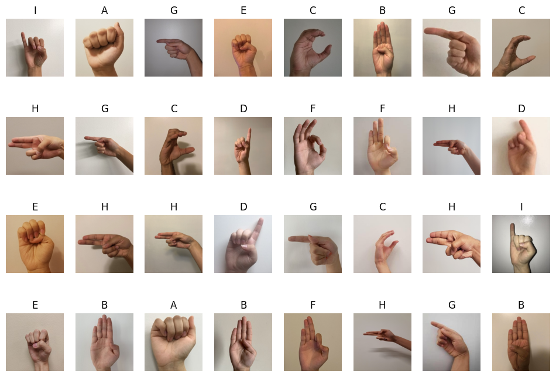

```python
# Define transformations for the images
transform = transforms.Compose([
    transforms.Resize((224, 224)),  # Resize images to a consistent size
    transforms.ToTensor(),  # Converts images to PyTorch tensors
])

# Visualize some of the images from the dataset

# datasets
train_dataset = datasets.ImageFolder(root=train_dir, transform=transform)
val_dataset = datasets.ImageFolder(root=val_dir, transform=transform)
test_dataset = datasets.ImageFolder(root=test_dir, transform=transform)

# data loaders
train_loader = torch.utils.data.DataLoader(train_dataset,batch_size = 32, shuffle=True)
val_loader = torch.utils.data.DataLoader(val_dataset,batch_size = 32, shuffle=True)
test_loader = torch.utils.data.DataLoader(test_dataset,batch_size = 32, shuffle=False)

# Get a batch of images and labels from the training data loader
batch = next(iter(train_loader))
images, labels = batch

# class names from the dataset
class_names = train_dataset.classes

# Show the images and labels in a grid without color modification
show_images_grid(images, labels, class_names)
plt.show()
```

## Part 2. Model Building and Sanity Checking [5pt]

### Part (i) Convolutional Network [2pt MODEL]

Build a convolutional neural network model that takes the (224x224 RGB) image as input, and predicts the gesture letter. Your model should be a subclass of nn.Module. Explain your choice of neural network architecture: how many layers did you choose? What types of layers did you use? Were they fully-connected or convolutional? What about other decisions like pooling layers, activation functions, number of channels / hidden units?

```python
# TO BE COMPLETED


class GestureCNN(nn.Module):
    def __init__(self, Ln=64, num_classes=9):
        # Call the constructor of the parent class
        super(GestureCNN, self).__init__()

        # Name of the model
        self.name = "Gesture"

        # First convolutional layer: Takes 3 input channels,
        # produces 16 output channels, kernel size 5x5
        self.conv1 = nn.Conv2d(3, 16, kernel_size=5)

        # Second convolutional layer: Takes 16 input channels,
        # produces 32 output channels, kernel size 3x3
        self.conv2 = nn.Conv2d(16, 32, kernel_size=3)

        # Third convolutional layer: Takes 32 input channels,
        # produces 64 output channels, kernel size 3x3
        self.conv3 = nn.Conv2d(32, 64, kernel_size=3)

        # Max pooling layer: Reduces the spatial dimensions by a factor of 2
        self.pool = nn.MaxPool2d(2, 2)

        # First fully connected layer: Takes flattened
        # input (64 * 26 * 26), produces Ln output units
        self.fc1 = nn.Linear(64 * 26 * 26, Ln)

        # Second fully connected layer (output layer):
        # Takes Ln input units, produces num_classes output units
        self.fc2 = nn.Linear(Ln, num_classes)

    # The forward method is responsible for defining the forward pass of the network
    def forward(self, x):
        # First convolutional layer with max pooling and ReLU activation
        x = self.pool(F.relu(self.conv1(x)))

        # Second convolutional layer with max pooling and ReLU activation
        x = self.pool(F.relu(self.conv2(x)))

        # Third convolutional layer with max pooling and ReLU activation
        x = self.pool(F.relu(self.conv3(x)))

        # Flatten the output for the fully connected layers
        x = x.view(-1, 64 * 26 * 26)

        # First fully connected layer with ReLU activation
        x = F.relu(self.fc1(x))

        # Second fully connected layer (output layer)
        x = self.fc2(x)

        return x
```

```python
'''
PROVIDE YOUR ANSWER BELOW

Abdullah: Replying to

"Explain your choice of neural network architecture: how many layers did you
choose? What types of layers did you use? Were they fully-connected or
convolutional? What about other decisions like pooling layers, activation
functions, number of channels / hidden units?"

-----------------------------------------------------------------------------

The chosen neural network architecture is designed for a hand gesture
classification task. The inspiration for the model was taken from the
pre-assignment codes and lecture slides:

Input Layer:
The input layer expects images with dimensions 224x224 and
three color channels (RGB).

Convolutional Layers:
Three convolutional layers (conv1, conv2, conv3) are used to
capture hierarchical features in the input images.
conv1 uses a 5x5 kernel size, followed by max pooling.
conv2 uses a 3x3 kernel size, followed by max pooling.
conv3 uses a 3x3 kernel size, followed by max pooling.

The number of output channels progressively increases (16, 32, 64),
allowing the network to learn more complex and abstract features.

Pooling Layers:
Max pooling layers follow each convolutional layer
to perform dimensionality reduction and provide translation invariance.

Pooling is performed with a 2x2 kernel and a stride of 2.

Activation Functions:
ReLU activation functions are applied after each convolutional layer.
ReLU introduces non-linearity to the model, helping it learn
complex mappings from inputs to outputs.

Flatten Layer:
Before the fully connected layers, a flatten operation is performed to
convert the 3D tensor to a 1D tensor, preparing it for the fully connected layers.

Fully Connected Layers:
Two fully connected layers (fc1, fc2) are included in the architecture.
The first fully connected layer (fc1) takes the flattened input and
produces Ln output units with a ReLU activation function.
The second fully connected layer (fc2) serves as the output layer,
taking Ln input units and producing num_classes output units.

Output Layer:
The model uses a linear activation in the output layer,
suitable for classification tasks, with as many units as there
are classes (A - I).

Number of Hidden Units:
The number of channels in convolutional layers and hidden units in the
fully connected layers (fc1 and fc2) was determined based on the
calculated dimensions.

The chosen architecture aims to capture relevant features from the input
images through convolutional and pooling operations, followed by classification
through fully connected layers. It strikes a balance between complexity and
simplicity, considering the task's requirements and the size of the dataset.
The use of multiple convolutional layers helps the model learn hierarchical
features, and max pooling aids in reducing spatial dimensions. The ReLU
activation functions introduce non-linearity, enhancing the model's capacity
to learn complex patterns in the data.


------------------------------------------------------------------------------

'''
```

### Part (ii) Training Code [2pt MODEL]

Write code that trains your neural network given some training data. Your training code should make it easy to tweak the usual hyperparameters, like batch size, learning rate, and the model object itself. Make sure that you are checkpointing your models from time to time (the frequency is up to you). Explain your choice of loss function and optimizer.

```python
# TO BE COMPLETED



def train_model(model, num_epochs, learning_rate, batch_size,ln):

    # Define the paths to the train, validation, and test sets
    train_dir = '/content/training'
    val_dir = '/content/validation'
    test_dir = '/content/test'

    # Define transformations for the images
    transform = transforms.Compose([
        transforms.Resize((224, 224)),  # Resize images to a consistent size
        transforms.ToTensor(),  # Converts images to PyTorch tensors
    ])

    # Create datasets
    train_dataset = datasets.ImageFolder(root=train_dir, transform=transform)
    val_dataset = datasets.ImageFolder(root=val_dir, transform=transform)
    test_dataset = datasets.ImageFolder(root=test_dir, transform=transform)

    # Create data loaders
    train_loader = DataLoader(train_dataset, batch_size=batch_size, shuffle=True)
    val_loader = DataLoader(val_dataset, batch_size=batch_size, shuffle=True)
    test_loader = DataLoader(test_dataset, batch_size=batch_size, shuffle=False)

    criterion = nn.CrossEntropyLoss()
    optimizer = optim.SGD(model.parameters(), lr=learning_rate, momentum=0.9)

    train_err = []
    train_loss = []
    val_err = []
    val_loss = []

    # Function to calculate error
    def calculate_error(outputs, labels):
        _, predicted = torch.max(outputs.data, 1)
        correct = (predicted == labels).sum().item()
        error = 1 - correct / labels.size(0)
        return error

    for epoch in range(num_epochs):
        model.train()
        running_loss = 0.0
        running_error = 0.0

        for inputs, labels in train_loader:
            optimizer.zero_grad()
            outputs = model(inputs)
            loss = criterion(outputs, labels)
            loss.backward()
            optimizer.step()
            running_loss += loss.item()
            running_error += calculate_error(outputs, labels)

        # Calculate training error and loss
        train_err.append(running_error / len(train_loader))
        train_loss.append(running_loss / len(train_loader))

        print(f'Epoch {epoch + 1}/{num_epochs}, Loss: {train_loss[-1]}, Train Error: {train_err[-1]}')

        # Validation
        model.eval()
        val_loss_epoch = 0.0
        correct = 0
        total = 0

        with torch.no_grad():
            for inputs, labels in val_loader:
                outputs = model(inputs)
                loss = criterion(outputs, labels)
                val_loss_epoch += loss.item()

                _, predicted = torch.max(outputs.data, 1)
                total += labels.size(0)
                correct += (predicted == labels).sum().item()

            # Calculate validation error and loss
            val_err.append(1 - correct / total)
            val_loss.append(val_loss_epoch / len(val_loader))

            print(f'Validation Loss: {val_loss[-1]}, Validation Error: {val_err[-1]}')

        model_path = get_model_name(model.name, batch_size, learning_rate, epoch,ln)
        torch.save(model.state_dict(), model_path)

    # Save metrics to CSV files
    np.savetxt("{}_train_err.csv".format(model_path), train_err)
    np.savetxt("{}_train_loss.csv".format(model_path), train_loss)
    np.savetxt("{}_val_err.csv".format(model_path), val_err)
    np.savetxt("{}_val_loss.csv".format(model_path), val_loss)
```

```python
'''
PROVIDE YOUR ANSWER BELOW


Abdullah: Replying to
"Explain your choice of loss function and optimizer."

-----------------------------------------------------------------------------
Before answering this question. A brief explanation of the code above training
code:

Data Preparation:
The code uses the ImageFolder dataset class from torchvision to
load images from specified directories for training, validation, and testing.
Transformations are applied to the images, resizing them to (224, 224)
and converting them to PyTorch tensors.

Model Definition:
The model is an instance of the GestureCNN class, which is a
convolutional neural network designed for gesture classification.

The model has convolutional layers followed by
max-pooling layers, and fully connected layers.

Loss Function and Optimizer:
The chosen loss function is Cross-Entropy Loss
(nn.CrossEntropyLoss()), which is suitable for multi-class
classification problems. We have multiple classes for this task. A - I.

Stochastic Gradient Descent (SGD) with momentum
is used as the optimizer, with a specified learning rate and momentum parameter.

Training Loop:
The training loop iterates over the specified number of epochs.
For each epoch, the model is set to training mode,
and the training data is processed in batches.
The model parameters are updated using backpropagationbased on the
computed loss.

Training metrics such as loss and error rate are calculated and printed.
After each epoch, the model is evaluated on the validation set to
monitor its performance.

Model Checkpointing:
The model's state is saved after each epoch using torch.save.
Additionally, training and validation metrics are saved to CSV files.


choice of loss function and optimizer:

Loss Function: Cross-Entropy Loss is a common choice for multi-class
classification tasks. It combines the softmax activation function and the
negative log likelihood loss, providing a suitable objective for training a
classification model.

Optimizer: Stochastic Gradient Descent (SGD) with momentum is a standard
optimization algorithm. The momentum term helps accelerate convergence,
and it is often effective in training deep neural networks.

In conclusion, the code is designed for training a gesture classification model
using a CNN architecture with Cross-Entropy Loss and SGD optimizer.

------------------------------------------------------------------------------



'''
```

### Part (iii) “Overfit” to a Small Dataset - [1pt MODEL]

One way to sanity check our neural network model and training code is to check whether the model is capable of “overfitting” or “memorizing” a small dataset. A properly constructed CNN with correct training code should be able to memorize the answers to a small number of images quickly.

Construct a small dataset (e.g. just the images that you have collected). Then show that your model and training code is capable of memorizing the labels of this small data set.

With a large batch size (e.g. the entire small dataset) and learning rate that is not too high, you should be able to obtain a 100% training accuracy on that small dataset relatively quickly (within 200 iterations).

```
Dataset extracted successfully.
```

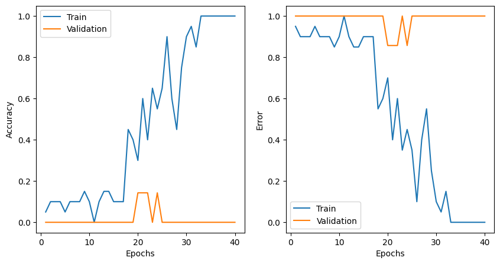

```python
# TO BE COMPLETED

'''
Abdullah: My own data is small and it can be used for overfit checking.
I am using my own data to see if the model is capable of overfitting on a
small dataset.

I will be running for some epochs as large number of epochs is not useful
if the training accuracy reaches 1.

'''

# Unzip the dataset
file_name = '/content/Rasul-Abdullah_1011328243.zip'
with ZipFile(file_name, 'r') as zip:
    zip.extractall()
    print('Dataset extracted successfully.')

# Define the paths to the dataset
dataset_path = '/content/Rasul-Abdullah_1011328243'

# Define transformations for the images
transform = transforms.Compose([
    transforms.Resize((224, 224)),
    transforms.ToTensor(),
])

# Create the dataset
full_dataset = datasets.ImageFolder(root=dataset_path, transform=transform)

# Define the indices for training and validation sets
total_samples = len(full_dataset)
train_size = int(0.75 * total_samples)
val_size = total_samples - train_size

indices = list(range(total_samples))
train_indices, val_indices = indices[:train_size], indices[train_size:]

# Create DataLoader for training and validation sets
train_sampler = SubsetRandomSampler(train_indices)
val_sampler = SubsetRandomSampler(val_indices)

train_loader = DataLoader(full_dataset,sampler=train_sampler, shuffle=False)
val_loader = DataLoader(full_dataset, sampler=val_sampler, shuffle=False)
# Initialize the model
model = GestureCNN(Ln = 128)

# Set hyperparameters
num_epochs = 40
learning_rate = 0.002

# Define loss function and optimizer
criterion = nn.CrossEntropyLoss()
optimizer = optim.SGD(model.parameters(), lr=learning_rate, momentum=0.9)

# Training loop
train_losses = []
val_losses = []
train_errors = []
val_errors = []

train_acc = []
val_acc = []

for epoch in range(num_epochs):
    # Training
    model.train()
    train_loss = 0.0
    correct_train = 0
    total_train = 0
    for inputs, labels in train_loader:
        optimizer.zero_grad()
        outputs = model(inputs)
        loss = criterion(outputs, labels)
        loss.backward()
        optimizer.step()
        train_loss += loss.item() * inputs.size(0)

        _, predicted = torch.max(outputs.data, 1)
        total_train += labels.size(0)
        correct_train += (predicted == labels).sum().item()

    train_accuracy = correct_train / total_train
    train_losses.append(train_loss / len(train_loader.dataset))
    train_errors.append(1 - train_accuracy)
    train_acc.append(train_accuracy)


    # Validation
    model.eval()
    val_loss = 0.0
    correct_val = 0
    total_val = 0
    with torch.no_grad():
        for inputs, labels in val_loader:
            outputs = model(inputs)
            loss = criterion(outputs, labels)
            val_loss += loss.item() * inputs.size(0)

            _, predicted = torch.max(outputs.data, 1)
            total_val += labels.size(0)
            correct_val += (predicted == labels).sum().item()

    val_accuracy = correct_val / total_val
    val_losses.append(val_loss / len(val_loader.dataset))
    val_errors.append(1 - val_accuracy)
    val_acc.append(val_accuracy)

    print(f'Epoch {epoch+1}/{num_epochs}, Train Loss: {train_losses[-1]:.4f}, Val Loss: {val_losses[-1]:.4f}, Train Error: {train_errors[-1]:.4f}, Val Error: {val_errors[-1]:.4f}')

# Plotting
plt.figure(figsize=(10, 5))
plt.subplot(1, 2, 1)
plt.plot(range(1, num_epochs+1), train_acc, label='Train')
plt.plot(range(1, num_epochs+1), val_acc, label='Validation')
plt.xlabel('Epochs')
plt.ylabel('Accuracy')
plt.legend()

plt.subplot(1, 2, 2)
plt.plot(range(1, num_epochs+1), train_errors, label='Train')
plt.plot(range(1, num_epochs+1), val_errors, label='Validation')
plt.xlabel('Epochs')
plt.ylabel('Error')
plt.legend()

plt.show()
```

## Part 3. Hyperparameter Search [7pt]

### Part (i) - [2pt EXPLORATORY]

List 3 hyperparameters that you think are most worth tuning. Choose at least one hyperparameter related to the model architecture.

```python
'''
PROVIDE YOUR ANSWER BELOW

------------------------------------------------------------------------

Learning Rate (lr):
The learning rate is a crucial hyperparameter that controls the step size
during the optimization process. A too high learning rate might cause the
model to converge too quickly or even overshoot the optimal weights, while a
too low learning rate might result in slow convergence or getting stuck in
local minima.

Batch Size:
Batch size determines the number of samples used in each iteration of the
training. A smaller batch size may result in a more stochastic gradient descent
and can help the model generalize better, while a larger batch size may lead to
faster convergence but might cause the model to
converge to a suboptimalsolution.

Number of Nodes in the Fully Connected Layers:
The architecture of the fully connected layers, including the number of
nodes in each layer, significantly impacts the model's capacity to learn
complex patterns and represent higher-level abstractions. Adjusting the
number of nodes in these layers can influence the model's ability to capture
and generalize from the learned features.

I will be tuning these hyperparameters for the next section.

--------------------------------------------------------------------------


'''
```

### Part (ii) - [1pt MODEL]

Tune the hyperparameters you listed in Part (i), trying as many values as you need to until you feel satisfied that you are getting a good model. Plot the training curve of at least 4 different hyperparameter settings.

```
Validation Loss: 2.1931532472372055, Validation Error: 0.8877338877338877
Validation Loss: 1.8996031880378723, Validation Error: 0.5571725571725572
Validation Loss: 2.0276107266545296, Validation Error: 0.7130977130977131
Validation Loss: 1.0426274705678225, Validation Error: 0.3783783783783784
Validation Loss: 1.0473717637360096, Validation Error: 0.3929313929313929
Validation Loss: 1.2148930691182613, Validation Error: 0.42411642411642414
Validation Loss: 0.918532544746995, Validation Error: 0.343035343035343
Validation Loss: 1.0310354866087437, Validation Error: 0.3201663201663202
Validation Loss: 0.8471259344369173, Validation Error: 0.2661122661122661
Validation Loss: 0.8502552546560764, Validation Error: 0.3014553014553014
Validation Loss: 0.827613789588213, Validation Error: 0.2577962577962578
Validation Loss: 0.7571566516999155, Validation Error: 0.2494802494802495
Validation Loss: 0.936725564301014, Validation Error: 0.2723492723492723
Validation Loss: 0.91482889445615, Validation Error: 0.2661122661122661
Validation Loss: 1.0596917401999235, Validation Error: 0.24740124740124736
Validation Loss: 1.0196226767584449, Validation Error: 0.2931392931392931
Validation Loss: 1.4025129154324532, Validation Error: 0.2577962577962578
Validation Loss: 1.0653492994606495, Validation Error: 0.2577962577962578
Validation Loss: 1.1481501111702528, Validation Error: 0.2557172557172557
Validation Loss: 1.0683005321770906, Validation Error: 0.22453222453222454


--- Model 1 - batch_size=32,learning_rate=0.01, Ln = 64 epochs=20 ---
```

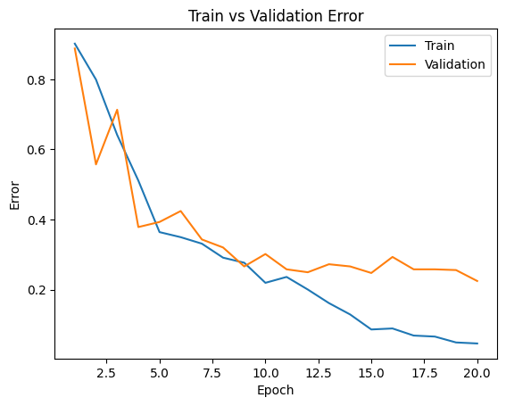

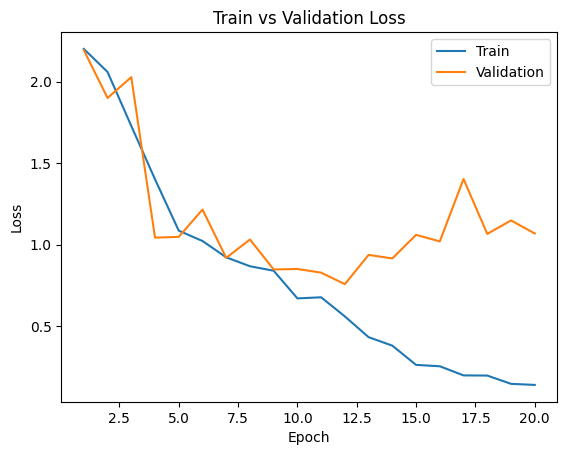

```python
# TO BE COMPLETED

# Settings No. 1: Lr = 0.01 BS = 32, Number of nodes in FC layers (Ln) = 64

model = GestureCNN()

train_model(model, num_epochs = 20, learning_rate = 0.01,
            batch_size = 32,ln=64)

model_path_1 = get_model_name("Gesture", batch_size=32,
                                  learning_rate=0.01, epoch=19,ln=64)

# Use plot_training_curve to display both training curves on the same plot
print("\n\n--- Model 1 - batch_size=32,learning_rate=0.01, Ln = 64 epochs=20 ---\n\n")
plot_training_curve(model_path_1)

#########################################################################
```

```
Validation Loss: 2.1882582902908325, Validation Error: 0.8295218295218295
Validation Loss: 2.0747110545635223, Validation Error: 0.7650727650727651
Validation Loss: 1.5948620736598969, Validation Error: 0.5530145530145529
Validation Loss: 1.2749584913253784, Validation Error: 0.49480249480249483
Validation Loss: 1.329102411866188, Validation Error: 0.49064449064449067
Validation Loss: 1.08047254383564, Validation Error: 0.4012474012474012
Validation Loss: 1.0389875397086143, Validation Error: 0.3721413721413721
Validation Loss: 1.02964136749506, Validation Error: 0.36798336798336795
Validation Loss: 1.0771569609642029, Validation Error: 0.2910602910602911
Validation Loss: 0.9712237790226936, Validation Error: 0.3222453222453222
Validation Loss: 0.8156903684139252, Validation Error: 0.24740124740124736
Validation Loss: 0.8857708498835564, Validation Error: 0.2931392931392931
Validation Loss: 1.037162646651268, Validation Error: 0.3139293139293139
Validation Loss: 0.796996459364891, Validation Error: 0.2224532224532224
Validation Loss: 0.770574226975441, Validation Error: 0.24740124740124736
Validation Loss: 0.7431636862456799, Validation Error: 0.2203742203742204
Validation Loss: 0.8269268125295639, Validation Error: 0.21829521829521825
Validation Loss: 0.7298405021429062, Validation Error: 0.21205821205821207
Validation Loss: 0.8066126778721809, Validation Error: 0.2203742203742204
Validation Loss: 0.9540760666131973, Validation Error: 0.21621621621621623


------ Model 2 - batch_size=64 ,learning_rate=0.01, Ln = 64 epochs=20 -----
```

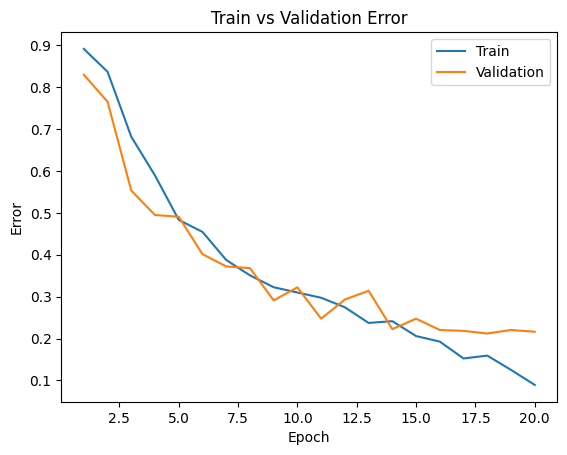

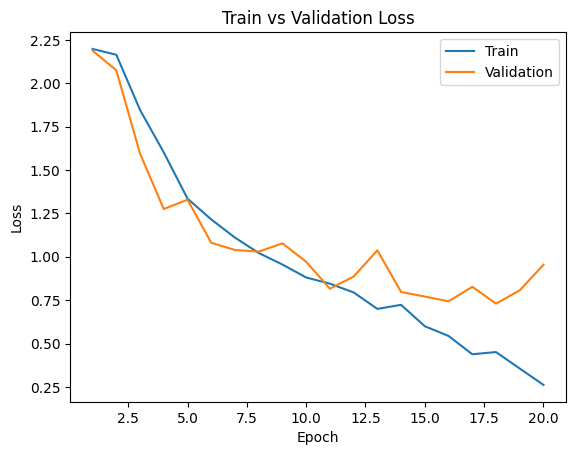

```python
# Settings No. 2: Lr = 0.01 BS = 64, Ln = 64


model = GestureCNN()

train_model(model, num_epochs = 20, learning_rate = 0.01,
            batch_size = 64, ln=64)

model_path_2 = get_model_name("Gesture", batch_size=64,
                                  learning_rate=0.01, epoch=19,ln=64)

# Use plot_training_curve to display both training curves on the same plot
print("\n\n------ Model 2 - batch_size=64 ,learning_rate=0.01, Ln = 64 epochs=20 -----\n\n")
plot_training_curve(model_path_2)

#########################################################################
```

```
Validation Loss: 2.200701057910919, Validation Error: 0.8877338877338877
Validation Loss: 2.196072995662689, Validation Error: 0.8877338877338877
Validation Loss: 2.1914169043302536, Validation Error: 0.8523908523908523
Validation Loss: 2.1912350207567215, Validation Error: 0.8856548856548856
Validation Loss: 2.1870013773441315, Validation Error: 0.8004158004158004
Validation Loss: 2.176010102033615, Validation Error: 0.6964656964656964
Validation Loss: 2.137713447213173, Validation Error: 0.7484407484407485
Validation Loss: 1.994316577911377, Validation Error: 0.7193347193347193
Validation Loss: 1.6380467861890793, Validation Error: 0.5966735966735967
Validation Loss: 1.2777409702539444, Validation Error: 0.422037422037422
Validation Loss: 1.1295673064887524, Validation Error: 0.3575883575883576
Validation Loss: 1.0797141455113888, Validation Error: 0.33264033264033266
Validation Loss: 0.9975997135043144, Validation Error: 0.3201663201663202
Validation Loss: 0.9886815529316664, Validation Error: 0.35966735966735963
Validation Loss: 1.0040645524859428, Validation Error: 0.3139293139293139
Validation Loss: 1.0870077162981033, Validation Error: 0.3076923076923077
Validation Loss: 1.089095652103424, Validation Error: 0.3222453222453222
Validation Loss: 1.052010279148817, Validation Error: 0.33887733887733884
Validation Loss: 1.0666341707110405, Validation Error: 0.31808731808731805
Validation Loss: 0.9565809657797217, Validation Error: 0.343035343035343


------ Model 3 - batch_size=32  ,learning_rate=0.001, Ln = 64 epochs=20 -----
```

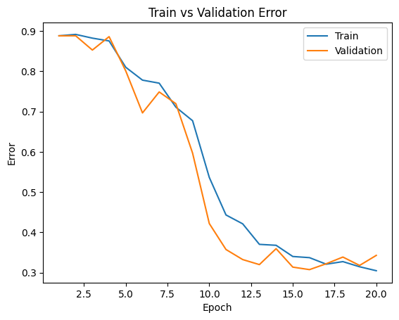

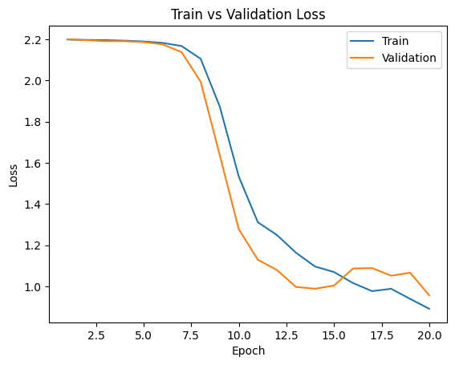

```python
# Settings No. 3: Lr = 0.001 BS = 32, Ln = 64


model = GestureCNN()

train_model(model, num_epochs = 20, learning_rate = 0.001,
            batch_size = 32, ln=64)

model_path_3 = get_model_name("Gesture", batch_size=32,
                                  learning_rate=0.001, epoch=19,ln=64)

# Use plot_training_curve to display both training curves on the same plot
print("\n\n------ Model 3 - batch_size=32  ,learning_rate=0.001, Ln = 64 epochs=20 -----\n\n")
plot_training_curve(model_path_3)
#########################################################################
```